# Principal Component Analysis: An Introduction with Examples in R

2019-02-14

## PCA

- Principle component analysis distributes the variation in a multivariate dataset across *components*.
- Visualize patterns that would not be apparent
- Linear algebra is at the heart of the PCA
- This discussion will be light on mathematical theory

## Accomplishing the PCA *Manually*

## Accomplishing the PCA *Manually*

- Goal for the *manual* PCA
- Become acquainted with the terminology and concepts in PCA
- Better prepared to defend your analysis

## Motivating Example - Wolf Spider Morphometrics

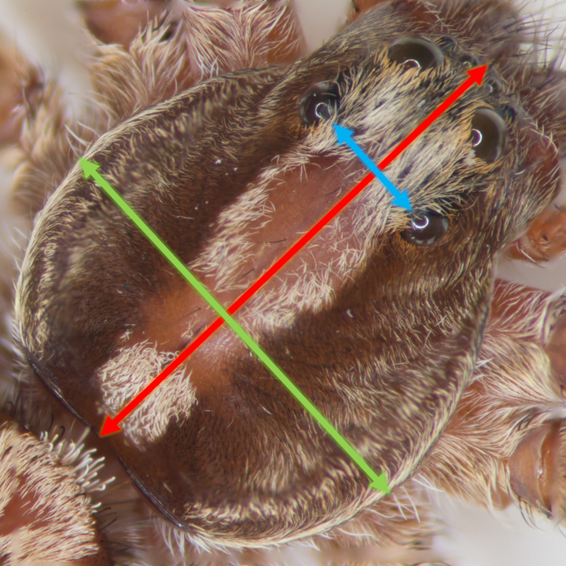

## Descriptive Statistics

|  | interoc | cwidth | clength | T.weight |
| --- | --- | --- | --- | --- |
| median | 0.798 | 2.975 | 3.706 | 1.740 |
| mean | 0.799 | 2.991 | 3.691 | 1.742 |
| SE.mean | 0.005 | 0.020 | 0.020 | 0.004 |
| CI.mean.0.95 | 0.011 | 0.039 | 0.039 | 0.008 |
| var | 0.002 | 0.028 | 0.028 | 0.001 |
| std.dev | 0.046 | 0.166 | 0.167 | 0.033 |
| coef.var | 0.058 | 0.055 | 0.045 | 0.019 |

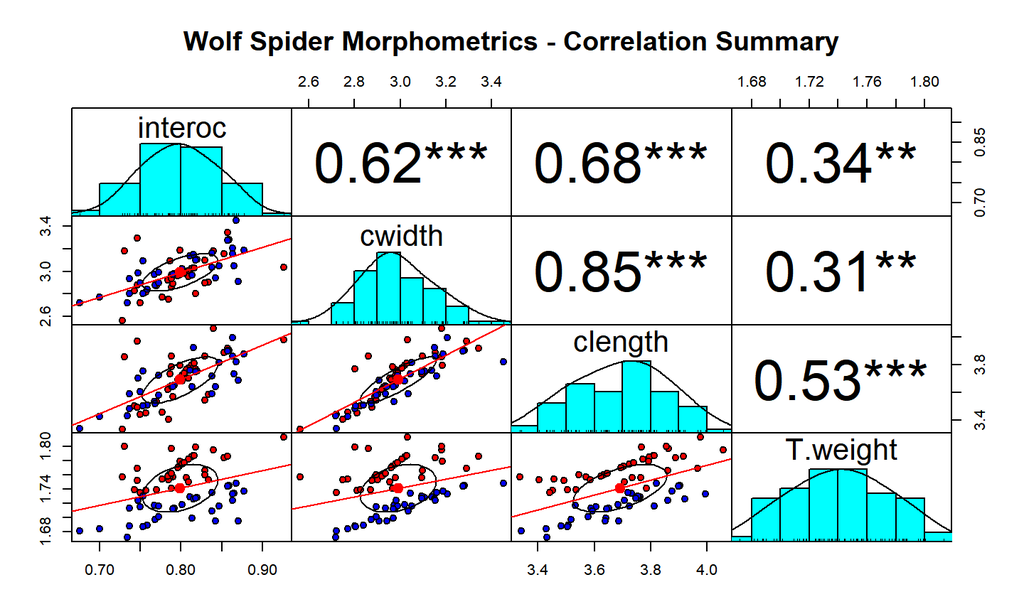

## Covariance or Correlation?

## Covariance or Correlation?

- Are the metrics in our dataset are *like* or *mixed*?
- Like: covariance matrix with mean-centering
- Mixed: correlation matrix with unit variance
- Becomes essential when using the built-in PCA functions in R

## Find the Eigenvalues & Eigenvectors

## Calculating Eigenvectors

```r
standardize <- function(x) {(x - mean(x))/sd(x)}

# Eliminate factor variables & untransformed weights
my.scaled.data <- as.data.frame(apply(morpho, 2, standardize))

# Calculate correlation matrix
my.cor <- cor(my.scaled.data)

# Save the eigenvalues of the correllation matrix
my.eigen <- eigen(my.cor)

# Rename matrix rows and columns for easier interpretation
rownames(my.eigen$vectors) <- c("interoc", "cwidth",
                                "clength", "T.weight")
colnames(my.eigen$vectors) <- c("PC1", "PC2", "PC3", "PC4")
```

## Calculating Eigenvectors

|  | PC1 | PC2 | PC3 | PC4 |
| --- | --- | --- | --- | --- |
| interoc | -0.4973 | -0.2504 | 0.8251 | -0.0960 |
| cwidth | -0.5319 | -0.3465 | -0.4948 | -0.5935 |
| clength | -0.5760 | -0.0463 | -0.2716 | 0.7696 |
| T.weight | -0.3716 | 0.9028 | 0.0250 | -0.2150 |

## Calculating Eigenvalues

| PC | eigenvalues |
| --- | --- |
| PC1 | 2.7104 |
| PC2 | 0.7608 |
| PC3 | 0.4128 |
| PC4 | 0.1160 |

## Calculating Eigenvalues

Sum of the eigenvalues = total variance of the scaled data

```r
sum(my.eigen$values)
```

```
## [1] 4
```

```r
sum(
  var(my.scaled.data[,1]),
  var(my.scaled.data[,2]),
  var(my.scaled.data[,3]),
  var(my.scaled.data[,4]))
```

```
## [1] 4
```

## Amount of Variation Captured by the PCs

## Variation Captured by the PCs

```r
pc1.var <- 100*round(my.eigen$values[1]/
                       sum(my.eigen$values), digits = 3)
pc2.var <- 100*round(my.eigen$values[2]/
                       sum(my.eigen$values), digits = 3)
pc3.var <- 100*round(my.eigen$values[3]/
                       sum(my.eigen$values), digits = 3)
pc4.var <- 100*round(my.eigen$values[4]/
                       sum(my.eigen$values), digits = 3)

pc <- data.frame(PC = c("PC1", "PC2", "PC3", "PC4"),
                 Percentage = c(pc1.var, pc2.var,
                                pc3.var, pc4.var))
```

## Variation Captured by the PCs

| PC | Percentage |
| --- | --- |
| PC1 | 67.8 |
| PC2 | 19.0 |
| PC3 | 10.3 |
| PC4 | 2.9 |

## Variation Captured by the PCs

The total variation should sum to ~100% depending on rounding error:

```
## [1] 100
```

## What are PCA “scores”?

## What are PCA “scores”?

- Express the loadings and scaled data as matrices, then multiply them together
- The result is a new matrix which expresses the data in terms of the PCs
- These are the PCA *scores*

## What are PCA “scores”?

```r
loadings <- my.eigen$vectors
my.scaled.matrix <- as.matrix(my.scaled.data)
# the function %*% is matrix multiplication
scores <- my.scaled.matrix %*% loadings
sd <- sqrt(my.eigen$values)
rownames(loadings) <- colnames(my.scaled.data)
```

## What are PCA “scores”?

| PC1 | PC2 | PC3 | PC4 |
| --- | --- | --- | --- |
| -2.2600 | 0.4796 | 0.1963 | -0.0511 |
| -1.2141 | 1.0328 | 0.0185 | 0.0859 |
| -2.9230 | 0.7367 | -0.3902 | 0.5873 |
| -1.0990 | 1.0164 | 0.0283 | 0.0654 |
| -0.5060 | 1.8150 | 0.8230 | 0.6192 |
| -0.3074 | 0.8778 | 0.0583 | -0.0498 |

## PCA with Native R Functions

## PCA with Native R Functions

The function `prcomp` is the primary tool for PCA in base R

```r
pca_morpho <- prcomp(morpho, center = TRUE, scale. = TRUE)

# Show the variables in the class "prcomp"
ls(pca_morpho)
```

```
## [1] "center"   "rotation" "scale"    "sdev"     "x"
```

## Summary output of the PCA

```r
pca_summary <- summary(pca_morpho)$importance %>%
  as.data.frame() %>%
  round(., digits = 3)
```

## Summary output of the PCA

|  | PC1 | PC2 | PC3 | PC4 |
| --- | --- | --- | --- | --- |
| Standard deviation | 1.646 | 0.872 | 0.642 | 0.341 |
| Proportion of Variance | 0.678 | 0.190 | 0.103 | 0.029 |
| Cumulative Proportion | 0.678 | 0.868 | 0.971 | 1.000 |

## Orthogonality of PCs

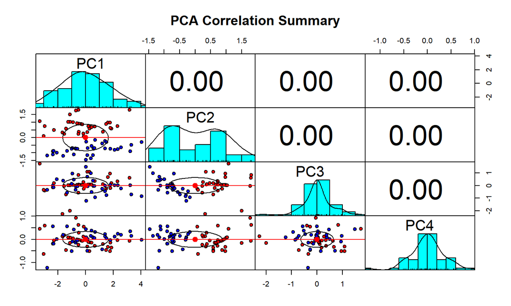

## Biplot

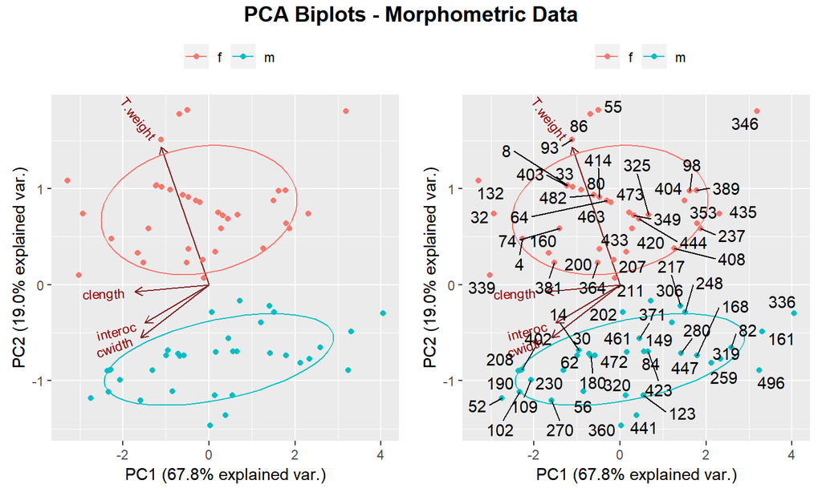

## How many PCs explain “enough” variation?

## Kaiser Criterion

- If an eigenvalue associated with a PC is \(\small >1\), then retain that component
- Compute the eigenvalues from the PCA: square the SDs in the `prcomp` object.

```
## [1] 2.7104296 0.7607956 0.4127988 0.1159759
```

## Parallel Analysis

Designed to reduce the subjectivity of interpreting a *scree plot*

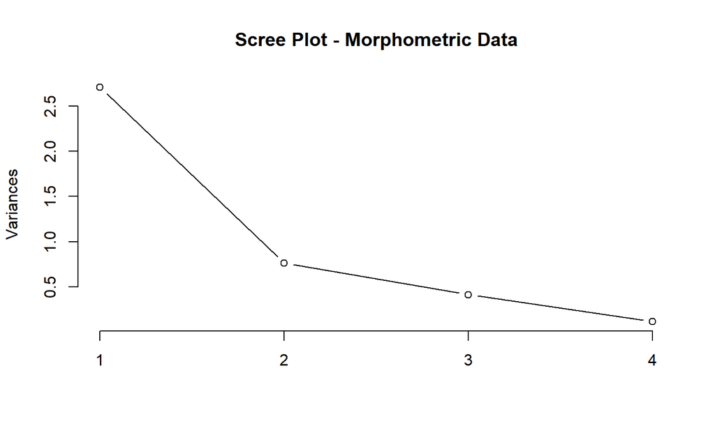

## Parallel Analysis

- Simulation-based method
- Generates thousands of data sets analogous to the “real” dataset
- Retain the number of factors that possess eigenvalues larger than the simulated data

## Parallel Analysis

```
##
## Using eigendecomposition of correlation matrix.
```

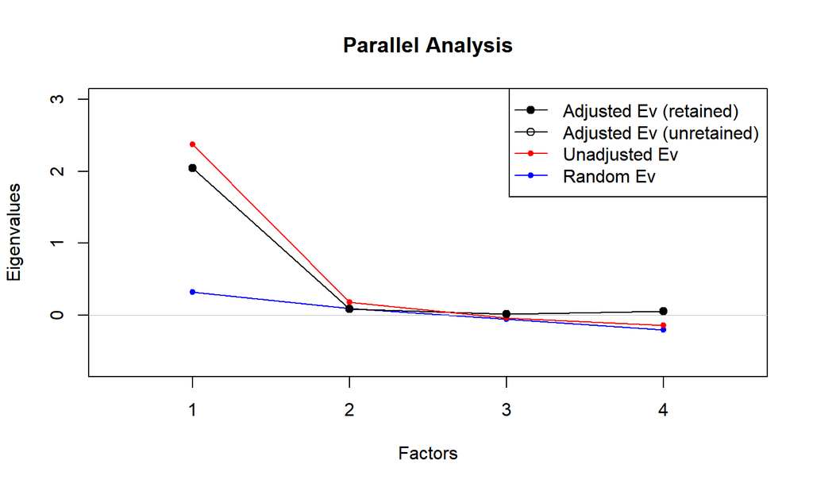

## PCA on the Oak Woods Dataset - Robust PCA

## PCA: Oak Woods Dataset

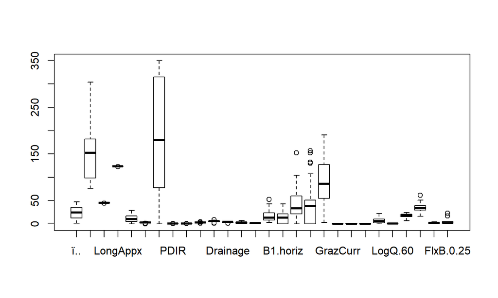

## PCA: Oak Woods Dataset

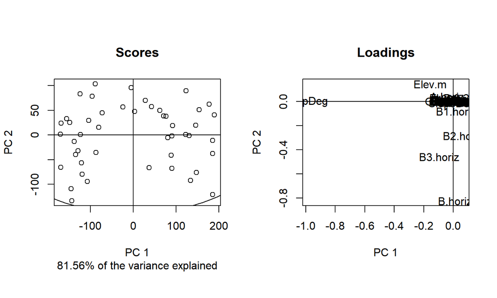

## PCA: Oak Woods Dataset

In Summary, a PCA of any type may not be an appropriate statistical approach for this dataset